# Cleaning hurricane observations with Dask

The data collected from NOAA NCDC source is just too large to clean with Pandas or Excel. With 350,000 x 200 in dense matrix, this data is larger than memory for a normal computer. Hence traditional packages such as Pandas cannot be used as they expect data to fit fully in memory.

Thus, in this sample, we use **Dask**, a distributed data analysis library. Functionally, Dask provides a `DataFrame` object that behaves similar to a traditional pandas `DataFrame` object. You can perform slicing, dicing, exploration on them. However transformative operations on the `DataFrame` get queued and are operated only when necessary. When executed, Dask will read data in chunks, distribute it to workers (be it cores on a single machine or multiple machines in a cluster set up) and collect the data back for you.

```python
from dask import delayed
import dask.dataframe as ddf
import pandas as pd
import matplotlib.pyplot as plt
%matplotlib inline
```

```python
csv_path = '/Users/atma6951/Documents/GIS_data/Analytics/hurricanes/from_noaa_ibtracks/csv_with_metadata/Allstorms.ibtracs_all.v03r09.csv'
```

### Read input data in CSV

```python
%%time
table_na_values=['-999.','-999','-999.000', '-1', '-1.0','0','0.0']
full_df = ddf.read_csv(csv_path, na_values=table_na_values, skiprows=1)
```

```
CPU times: user 1.33 s, sys: 187 ms, total: 1.52 s
Wall time: 1.52 s
```

```python
full_df.head()
```

|  | Serial_Num | Season | Num | Basin | Sub_basin | Name | ISO_time | Nature | Latitude | Longitude | ... | jtwc_??_wrad34_rad3 | jtwc_??_wrad34_rad4 | jtwc_??_wrad50_rad1 | jtwc_??_wrad50_rad2 | jtwc_??_wrad50_rad3 | jtwc_??_wrad50_rad4 | jtwc_??_wrad64_rad1 | jtwc_??_wrad64_rad2 | jtwc_??_wrad64_rad3 | jtwc_??_wrad64_rad4 |
| --- | --- | --- | --- | --- | --- | --- | --- | --- | --- | --- | --- | --- | --- | --- | --- | --- | --- | --- | --- | --- | --- |
| 0 | 1842298N11080 | 1842 | 1 | NI | BB | NOT NAMED | 1842-10-25 06:00:00 | NR | NaN | NaN | ... | NaN | NaN | NaN | NaN | NaN | NaN | NaN | NaN | NaN | NaN |
| 1 | 1842298N11080 | 1842 | 1 | NI | BB | NOT NAMED | 1842-10-25 12:00:00 | NR | NaN | NaN | ... | NaN | NaN | NaN | NaN | NaN | NaN | NaN | NaN | NaN | NaN |
| 2 | 1842298N11080 | 1842 | 1 | NI | AS | NOT NAMED | 1842-10-25 18:00:00 | NR | NaN | NaN | ... | NaN | NaN | NaN | NaN | NaN | NaN | NaN | NaN | NaN | NaN |
| 3 | 1842298N11080 | 1842 | 1 | NI | AS | NOT NAMED | 1842-10-26 00:00:00 | NR | NaN | NaN | ... | NaN | NaN | NaN | NaN | NaN | NaN | NaN | NaN | NaN | NaN |
| 4 | 1842298N11080 | 1842 | 1 | NI | AS | NOT NAMED | 1842-10-26 06:00:00 | NR | NaN | NaN | ... | NaN | NaN | NaN | NaN | NaN | NaN | NaN | NaN | NaN | NaN |

5 rows × 200 columns

```python
all_columns=list(full_df.columns)
len(all_columns)
```

```
200
```

```python
from pprint import pprint
pprint(all_columns, compact=True, width=100)
```

```
['Serial_Num', 'Season', 'Num', 'Basin', 'Sub_basin', 'Name', 'ISO_time', 'Nature', 'Latitude',
 'Longitude', 'Wind(WMO)', 'Pres(WMO)', 'Center', 'Wind(WMO) Percentile', 'Pres(WMO) Percentile',
 'Track_type', 'Latitude_for_mapping', 'Longitude_for_mapping', 'Current Basin', 'hurdat_atl_lat',
 'hurdat_atl_lon', 'hurdat_atl_grade', 'hurdat_atl_wind', 'hurdat_atl_pres', 'td9636_lat',
 'td9636_lon', 'td9636_grade', 'td9636_wind', 'td9636_pres', 'reunion_lat', 'reunion_lon',
 'reunion_grade', 'reunion_wind', 'reunion_pres', 'atcf_lat', 'atcf_lon', 'atcf_grade', 'atcf_wind',
 'atcf_pres', 'mlc_natl_lat', 'mlc_natl_lon', 'mlc_natl_grade', 'mlc_natl_wind', 'mlc_natl_pres',
 'ds824_sh_lat', 'ds824_sh_lon', 'ds824_sh_grade', 'ds824_sh_wind', 'ds824_sh_pres', 'ds824_ni_lat',
 'ds824_ni_lon', 'ds824_ni_grade', 'ds824_ni_wind', 'ds824_ni_pres', 'bom_lat', 'bom_lon',
 'bom_grade', 'bom_wind', 'bom_pres', 'ds824_au_lat', 'ds824_au_lon', 'ds824_au_grade',
 'ds824_au_wind', 'ds824_au_pres', 'jtwc_sh_lat', 'jtwc_sh_lon', 'jtwc_sh_grade', 'jtwc_sh_wind',
 'jtwc_sh_pres', 'jtwc_wp_lat', 'jtwc_wp_lon', 'jtwc_wp_grade', 'jtwc_wp_wind', 'jtwc_wp_pres',
 'td9635_lat', 'td9635_lon', 'td9635_grade', 'td9635_wind', 'td9635_pres', 'ds824_wp_lat',
 'ds824_wp_lon', 'ds824_wp_grade', 'ds824_wp_wind', 'ds824_wp_pres', 'jtwc_io_lat', 'jtwc_io_lon',
 'jtwc_io_grade', 'jtwc_io_wind', 'jtwc_io_pres', 'cma_lat', 'cma_lon', 'cma_grade', 'cma_wind',
 'cma_pres', 'hurdat_epa_lat', 'hurdat_epa_lon', 'hurdat_epa_grade', 'hurdat_epa_wind',
 'hurdat_epa_pres', 'jtwc_ep_lat', 'jtwc_ep_lon', 'jtwc_ep_grade', 'jtwc_ep_wind', 'jtwc_ep_pres',
 'ds824_ep_lat', 'ds824_ep_lon', 'ds824_ep_grade', 'ds824_ep_wind', 'ds824_ep_pres', 'jtwc_cp_lat',
 'jtwc_cp_lon', 'jtwc_cp_grade', 'jtwc_cp_wind', 'jtwc_cp_pres', 'tokyo_lat', 'tokyo_lon',
 'tokyo_grade', 'tokyo_wind', 'tokyo_pres', 'neumann_lat', 'neumann_lon', 'neumann_grade',
 'neumann_wind', 'neumann_pres', 'hko_lat', 'hko_lon', 'hko_grade', 'hko_wind', 'hko_pres',
 'cphc_lat', 'cphc_lon', 'cphc_grade', 'cphc_wind', 'cphc_pres', 'wellington_lat', 'wellington_lon',
 'wellington_grade', 'wellington_wind', 'wellington_pres', 'newdelhi_lat', 'newdelhi_lon',
 'newdelhi_grade', 'newdelhi_wind', 'newdelhi_pres', 'nadi_lat', 'nadi_lon', 'nadi_grade',
 'nadi_wind', 'nadi_pres', 'reunion_rmw', 'reunion_wind_radii_1_ne', 'reunion_wind_radii_1_se',
 'reunion_wind_radii_1_sw', 'reunion_wind_radii_1_nw', 'reunion_wind_radii_2_ne',
 'reunion_wind_radii_2_se', 'reunion_wind_radii_2_sw', 'reunion_wind_radii_2_nw',
 'bom_mn_hurr_xtnt', 'bom_mn_gale_xtnt', 'bom_mn_eye_diam', 'bom_roci', 'atcf_rmw', 'atcf_poci',
 'atcf_roci', 'atcf_eye', 'atcf_wrad34_rad1', 'atcf_wrad34_rad2', 'atcf_wrad34_rad3',
 'atcf_wrad34_rad4', 'atcf_wrad50_rad1', 'atcf_wrad50_rad2', 'atcf_wrad50_rad3', 'atcf_wrad50_rad4',
 'atcf_wrad64_rad1', 'atcf_wrad64_rad2', 'atcf_wrad64_rad3', 'atcf_wrad64_rad4', 'tokyo_dir50',
 'tokyo_long50', 'tokyo_short50', 'tokyo_dir30', 'tokyo_long30', 'tokyo_short30', 'jtwc_??_rmw',
 'jtwc_??_poci', 'jtwc_??_roci', 'jtwc_??_eye', 'jtwc_??_wrad34_rad1', 'jtwc_??_wrad34_rad2',
 'jtwc_??_wrad34_rad3', 'jtwc_??_wrad34_rad4', 'jtwc_??_wrad50_rad1', 'jtwc_??_wrad50_rad2',
 'jtwc_??_wrad50_rad3', 'jtwc_??_wrad50_rad4', 'jtwc_??_wrad64_rad1', 'jtwc_??_wrad64_rad2',
 'jtwc_??_wrad64_rad3', 'jtwc_??_wrad64_rad4']
```

Reading the metadata from NOAA NCDC site, we find sensor measurements get unique columns if they are collected by a different agency. Thus we find multiple **pressure**, **wind speed**, **latitude**, **longitude**, etc. columns with different suffixes and prefixes. Data is sparse as it gets distributed between these columns. For our geospatial analysis, it suffices if we can merge these columns together and get location information from the co-ordinates.

### Merge all location columns

Below we prototype merging location columns. If this succeeds, we will proceed to merge all remaining columns

```python
lat_columns = [x for x in all_columns if 'lat' in x.lower()]
lon_columns = [x for x in all_columns if 'lon' in x.lower()]
for x in zip(lat_columns, lon_columns):
    print(x)
```

```
('Latitude', 'Longitude')
('Latitude_for_mapping', 'Longitude_for_mapping')
('hurdat_atl_lat', 'hurdat_atl_lon')
('td9636_lat', 'td9636_lon')
('reunion_lat', 'reunion_lon')
('atcf_lat', 'atcf_lon')
('mlc_natl_lat', 'mlc_natl_lon')
('ds824_sh_lat', 'ds824_sh_lon')
('ds824_ni_lat', 'ds824_ni_lon')
('bom_lat', 'bom_lon')
('ds824_au_lat', 'ds824_au_lon')
('jtwc_sh_lat', 'jtwc_sh_lon')
('jtwc_wp_lat', 'jtwc_wp_lon')
('td9635_lat', 'td9635_lon')
('ds824_wp_lat', 'ds824_wp_lon')
('jtwc_io_lat', 'jtwc_io_lon')
('cma_lat', 'cma_lon')
('hurdat_epa_lat', 'hurdat_epa_lon')
('jtwc_ep_lat', 'jtwc_ep_lon')
('ds824_ep_lat', 'ds824_ep_lon')
('jtwc_cp_lat', 'jtwc_cp_lon')
('tokyo_lat', 'tokyo_lon')
('neumann_lat', 'neumann_lon')
('hko_lat', 'hko_lon')
('cphc_lat', 'cphc_lon')
('wellington_lat', 'wellington_lon')
('newdelhi_lat', 'newdelhi_lon')
('nadi_lat', 'nadi_lon')
```

Let us define a custom function that will pick median value for a row, from a given list of columns. This way, we can consolidate latitude / longitude information from all the agencies.

```python
def pick_median_value(row, col_list):
    return row[col_list].median()
```

```python
%%time
full_df['latitude_merged'] = full_df.apply(pick_median_value, axis=1,
                                          col_list = lat_columns)
```

```
CPU times: user 47.1 ms, sys: 4.77 ms, total: 51.9 ms
Wall time: 49.3 ms
```

```python
%%time
full_df['longitude_merged'] = full_df.apply(pick_median_value, axis=1,
                                          col_list = lon_columns)
```

```
CPU times: user 45 ms, sys: 3.48 ms, total: 48.4 ms
Wall time: 45.5 ms
```

With `dask`, the above operation was delayed and stored in a queue. It has not been evaluated yet. Next, let us evaluate for `5` records and print output. If results look good, we will merge all remaining related columns together.

```python
%%time
full_df.head(5)
```

```
CPU times: user 1min 29s, sys: 2.1 s, total: 1min 31s
Wall time: 1min 31s
```

|  | Serial_Num | Season | Num | Basin | Sub_basin | Name | ISO_time | Nature | Latitude | Longitude | ... | jtwc_??_wrad50_rad1 | jtwc_??_wrad50_rad2 | jtwc_??_wrad50_rad3 | jtwc_??_wrad50_rad4 | jtwc_??_wrad64_rad1 | jtwc_??_wrad64_rad2 | jtwc_??_wrad64_rad3 | jtwc_??_wrad64_rad4 | latitude_merged | longitude_merged |
| --- | --- | --- | --- | --- | --- | --- | --- | --- | --- | --- | --- | --- | --- | --- | --- | --- | --- | --- | --- | --- | --- |
| 0 | 1842298N11080 | 1842 | 1 | NI | BB | NOT NAMED | 1842-10-25 06:00:00 | NR | NaN | NaN | ... | NaN | NaN | NaN | NaN | NaN | NaN | NaN | NaN | 10.885 | 79.815 |
| 1 | 1842298N11080 | 1842 | 1 | NI | BB | NOT NAMED | 1842-10-25 12:00:00 | NR | NaN | NaN | ... | NaN | NaN | NaN | NaN | NaN | NaN | NaN | NaN | 10.810 | 78.890 |
| 2 | 1842298N11080 | 1842 | 1 | NI | AS | NOT NAMED | 1842-10-25 18:00:00 | NR | NaN | NaN | ... | NaN | NaN | NaN | NaN | NaN | NaN | NaN | NaN | 10.795 | 77.910 |
| 3 | 1842298N11080 | 1842 | 1 | NI | AS | NOT NAMED | 1842-10-26 00:00:00 | NR | NaN | NaN | ... | NaN | NaN | NaN | NaN | NaN | NaN | NaN | NaN | 10.795 | 76.915 |
| 4 | 1842298N11080 | 1842 | 1 | NI | AS | NOT NAMED | 1842-10-26 06:00:00 | NR | NaN | NaN | ... | NaN | NaN | NaN | NaN | NaN | NaN | NaN | NaN | 10.805 | 75.820 |

5 rows × 202 columns

The results look good. Two additional columns(`latitude_merged`, `longitude_merged`) have been added. Thus by merging related columns, the redundant sparse columns can be removed and thereby simplifying the dimension of the input dataset.

Now that this prototype looks good, we will proceed by identifying the lists of columns that are redundant and can be merged.

### Merge similar columns

To keep track of which columns have been accounted for, we will duplicate the `all_columns` list and remove ones that we have identified.

```python
from copy import deepcopy
columns_tracker = deepcopy(all_columns)
len(columns_tracker)
```

```
200
```

From the `columns_tracker` list, let us remove the redundant columns we already identified for location columns:

```python
columns_tracker = [x for x in columns_tracker if x not in lat_columns]
columns_tracker = [x for x in columns_tracker if x not in lon_columns]
len(columns_tracker)
```

```
142
```

Thus, we have reduced the number of columns from `200` to `142`. We progressively reduce this while retaining key information.

#### Merge wind columns

Wind, pressure, grade are some of the measurement columns. To start off, let us identify the wind columns:

```python
# pick all columns that have 'wind' in name
wind_columns = [x for x in columns_tracker if 'wind' in x.lower()]

# based on metadata doc, we decide to eliminate percentile and wind distance columns
columns_to_eliminate = [x for x in wind_columns if 'radii' in x or 'percentile' in x.lower()]

# trim wind_columns by removing the ones we need to eliminate
wind_columns = [x for x in wind_columns if x not in columns_to_eliminate]
wind_columns
```

```
['Wind(WMO)',
 'hurdat_atl_wind',
 'td9636_wind',
 'reunion_wind',
 'atcf_wind',
 'mlc_natl_wind',
 'ds824_sh_wind',
 'ds824_ni_wind',
 'bom_wind',
 'ds824_au_wind',
 'jtwc_sh_wind',
 'jtwc_wp_wind',
 'td9635_wind',
 'ds824_wp_wind',
 'jtwc_io_wind',
 'cma_wind',
 'hurdat_epa_wind',
 'jtwc_ep_wind',
 'ds824_ep_wind',
 'jtwc_cp_wind',
 'tokyo_wind',
 'neumann_wind',
 'hko_wind',
 'cphc_wind',
 'wellington_wind',
 'newdelhi_wind',
 'nadi_wind']
```

```python
%%time
full_df['wind_merged'] = full_df.apply(pick_median_value, axis=1,
                                          col_list = wind_columns)
```

```
CPU times: user 48.5 ms, sys: 5.47 ms, total: 53.9 ms
Wall time: 50.9 ms
```

#### Merge pressure columns

We proceed to identify all `pressure` columns. But before that, we update the `columns_tracker` list by removing those we identified for wind:

```python
columns_tracker = [x for x in columns_tracker if x not in wind_columns]
columns_tracker = [x for x in columns_tracker if x not in columns_to_eliminate]
len(columns_tracker)
```

```
106
```

```python
# pick all columns that have 'pres' in name
pressure_columns = [x for x in columns_tracker if 'pres' in x.lower()]

# from metadata, we eliminate percentile and pres distance columns
if columns_to_eliminate:
    columns_to_eliminate.extend([x for x in pressure_columns if 'radii' in x or 'percentile' in x.lower()])
else:
    columns_to_eliminate = [x for x in pressure_columns if 'radii' in x or 'percentile' in x.lower()]

# trim wind_columns by removing the ones we need to eliminate
pressure_columns = [x for x in pressure_columns if x not in columns_to_eliminate]
pressure_columns
```

```
['Pres(WMO)',
 'hurdat_atl_pres',
 'td9636_pres',
 'reunion_pres',
 'atcf_pres',
 'mlc_natl_pres',
 'ds824_sh_pres',
 'ds824_ni_pres',
 'bom_pres',
 'ds824_au_pres',
 'jtwc_sh_pres',
 'jtwc_wp_pres',
 'td9635_pres',
 'ds824_wp_pres',
 'jtwc_io_pres',
 'cma_pres',
 'hurdat_epa_pres',
 'jtwc_ep_pres',
 'ds824_ep_pres',
 'jtwc_cp_pres',
 'tokyo_pres',
 'neumann_pres',
 'hko_pres',
 'cphc_pres',
 'wellington_pres',
 'newdelhi_pres',
 'nadi_pres']
```

```python
%%time
full_df['pressure_merged'] = full_df.apply(pick_median_value, axis=1,
                                          col_list = pressure_columns)
```

```
CPU times: user 45.1 ms, sys: 3.41 ms, total: 48.6 ms
Wall time: 45.7 ms
```

#### Merge grade columns

```python
columns_tracker = [x for x in columns_tracker if x not in pressure_columns]
columns_tracker = [x for x in columns_tracker if x not in columns_to_eliminate]
len(columns_tracker)
```

```
78
```

Notice the length of `columns_tracker` is reducing progressively as we identify redundant columns.

```python
# pick all columns that have 'grade' in name
grade_columns = [x for x in columns_tracker if 'grade' in x.lower()]
grade_columns
```

```
['hurdat_atl_grade',
 'td9636_grade',
 'reunion_grade',
 'atcf_grade',
 'mlc_natl_grade',
 'ds824_sh_grade',
 'ds824_ni_grade',
 'bom_grade',
 'ds824_au_grade',
 'jtwc_sh_grade',
 'jtwc_wp_grade',
 'td9635_grade',
 'ds824_wp_grade',
 'jtwc_io_grade',
 'cma_grade',
 'hurdat_epa_grade',
 'jtwc_ep_grade',
 'ds824_ep_grade',
 'jtwc_cp_grade',
 'tokyo_grade',
 'neumann_grade',
 'hko_grade',
 'cphc_grade',
 'wellington_grade',
 'newdelhi_grade',
 'nadi_grade']
```

```python
%%time
full_df['grade_merged'] = full_df.apply(pick_median_value, axis=1,
                                          col_list = grade_columns)
```

```
CPU times: user 45.8 ms, sys: 3.54 ms, total: 49.3 ms
Wall time: 46.4 ms
```

#### Merge eye diameter columns

```python
columns_tracker = [x for x in columns_tracker if x not in grade_columns]
len(columns_tracker)
```

```
52
```

```python
# pick all columns that have 'grade' in name
eye_dia_columns = [x for x in columns_tracker if 'eye' in x.lower()]
eye_dia_columns
```

```
['bom_mn_eye_diam', 'atcf_eye', 'jtwc_??_eye']
```

```python
%%time
full_df['eye_dia_merged'] = full_df.apply(pick_median_value, axis=1,
                                          col_list = eye_dia_columns)
```

```
CPU times: user 46.6 ms, sys: 3.2 ms, total: 49.8 ms
Wall time: 47.2 ms
```

#### Identify remaining redundant columns

```python
columns_tracker = [x for x in columns_tracker if x not in eye_dia_columns]
len(columns_tracker)
```

```
49
```

We are down to `49` columns, let us visualize what those look like.

```python
pprint(columns_tracker, width=119, compact=True)
```

```
['Serial_Num', 'Season', 'Num', 'Basin', 'Sub_basin', 'Name', 'ISO_time', 'Nature', 'Center', 'Track_type',
 'Current Basin', 'reunion_rmw', 'bom_mn_hurr_xtnt', 'bom_mn_gale_xtnt', 'bom_roci', 'atcf_rmw', 'atcf_poci',
 'atcf_roci', 'atcf_wrad34_rad1', 'atcf_wrad34_rad2', 'atcf_wrad34_rad3', 'atcf_wrad34_rad4', 'atcf_wrad50_rad1',
 'atcf_wrad50_rad2', 'atcf_wrad50_rad3', 'atcf_wrad50_rad4', 'atcf_wrad64_rad1', 'atcf_wrad64_rad2',
 'atcf_wrad64_rad3', 'atcf_wrad64_rad4', 'tokyo_dir50', 'tokyo_short50', 'tokyo_dir30', 'tokyo_short30', 'jtwc_??_rmw',
 'jtwc_??_poci', 'jtwc_??_roci', 'jtwc_??_wrad34_rad1', 'jtwc_??_wrad34_rad2', 'jtwc_??_wrad34_rad3',
 'jtwc_??_wrad34_rad4', 'jtwc_??_wrad50_rad1', 'jtwc_??_wrad50_rad2', 'jtwc_??_wrad50_rad3', 'jtwc_??_wrad50_rad4',
 'jtwc_??_wrad64_rad1', 'jtwc_??_wrad64_rad2', 'jtwc_??_wrad64_rad3', 'jtwc_??_wrad64_rad4']
```

Based on metadata shared by data provider, we choose to retain only the first `11` columns. We add the rest to the list `columns_to_eliminate`.

```python
columns_to_eliminate.extend(columns_tracker[11:])
pprint(columns_to_eliminate, width=119, compact=True)
```

```
['Wind(WMO) Percentile', 'reunion_wind_radii_1_ne', 'reunion_wind_radii_1_se', 'reunion_wind_radii_1_sw',
 'reunion_wind_radii_1_nw', 'reunion_wind_radii_2_ne', 'reunion_wind_radii_2_se', 'reunion_wind_radii_2_sw',
 'reunion_wind_radii_2_nw', 'Pres(WMO) Percentile', 'reunion_rmw', 'bom_mn_hurr_xtnt', 'bom_mn_gale_xtnt', 'bom_roci',
 'atcf_rmw', 'atcf_poci', 'atcf_roci', 'atcf_wrad34_rad1', 'atcf_wrad34_rad2', 'atcf_wrad34_rad3', 'atcf_wrad34_rad4',
 'atcf_wrad50_rad1', 'atcf_wrad50_rad2', 'atcf_wrad50_rad3', 'atcf_wrad50_rad4', 'atcf_wrad64_rad1',
 'atcf_wrad64_rad2', 'atcf_wrad64_rad3', 'atcf_wrad64_rad4', 'tokyo_dir50', 'tokyo_short50', 'tokyo_dir30',
 'tokyo_short30', 'jtwc_??_rmw', 'jtwc_??_poci', 'jtwc_??_roci', 'jtwc_??_wrad34_rad1', 'jtwc_??_wrad34_rad2',
 'jtwc_??_wrad34_rad3', 'jtwc_??_wrad34_rad4', 'jtwc_??_wrad50_rad1', 'jtwc_??_wrad50_rad2', 'jtwc_??_wrad50_rad3',
 'jtwc_??_wrad50_rad4', 'jtwc_??_wrad64_rad1', 'jtwc_??_wrad64_rad2', 'jtwc_??_wrad64_rad3', 'jtwc_??_wrad64_rad4']
```

#### Drop all redundant columns

```python
len(full_df.columns)
```

```
206
```

```python
columns_to_drop = lat_columns + lon_columns + wind_columns + pressure_columns + \
                    grade_columns + eye_dia_columns+columns_to_eliminate
len(columns_to_drop)
```

```
189
```

### Perform delayed computation

In Dask, all computations are delayed and queued. The `apply()` functions called earlier are not executed yet, however respective columns have been created as you can see from the DataFrame display above. In the cells below, we will call `compute()` to make Dask compute on this larger than memory dataset.

Calling `visualize()` on the delayed compute operation or the `DataFrame` object will plot the dask task queue as shown below. The graphic below provides a glimpse on how Dask distributes its tasks and how it reads this 'larger than memory dataset' in chunks and operates on them.

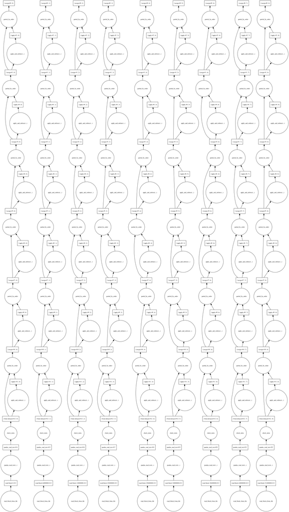

```python
full_df.visualize()
```

Below we perform execute all column merge operations that we have queued so far and drop the redundant columns. We store the resulting `DataFrame` in a new variable.

```python
%%time
merged_df = full_df.drop(columns_to_drop, axis=1).compute()
```

```
CPU times: user 42min 33s, sys: 5min 44s, total: 48min 17s
Wall time: 44min 25s
```

The graphic below shows the CPU usage before, and during computaiton.

[figure not shown]

```python
%%time
merged_df = full_df.drop(columns_to_drop, axis=1).compute()
```

```
CPU times: user 1h 49min 12s, sys: 15min 47s, total: 2h 5min
Wall time: 16h 54min 31s
```

The above operation took **1 hour, 49 min** to complete. Since the machine went to sleep midway, the wall time is reported as *16 hours*. The column drop operation returns a pandas DataFrame object that is stored in a new variable called `merged_df`.

#### Preview results

```python
merged_df.shape
```

```
(344806, 17)
```

Once you call `compute()` on a Dask DataFrame, you are returned a pandas DataFarme which is fully loaded into your memory. As you can see below, the data types and their corresponding sizes differ.

```python
(type(merged_df), type(full_df))
```

```
(pandas.core.frame.DataFrame, dask.dataframe.core.DataFrame)
```

```python
(print(str(getsizeof(merged_df)/(1000*1000)) + " mb"), print(str(getsizeof(full_df)/(1000)) + " kb"))
```

```
216.2479 mb
0.056 kb
```

```
(None, None)
```

### Write results to disk

So far, with dask, we have successfully read a larger than memory dataset, cleaned its columns and reduced the dimensions. The resulting dataset, still large, can be read into a pandas DataFrame for exploratory analysis.

Since the computation has been running for over 3 hours, it is safer to store the intermediate results to disk, so it can be read later.

```python
%%time
import os
merged_csv_path = os.path.join(os.path.split(csv_path)[0], "col_merged_csv2.csv")
merged_df.to_csv(merged_csv_path)
```

```
CPU times: user 3.54 s, sys: 168 ms, total: 3.7 s
Wall time: 3.84 s
```

## Explore data density

```python
merged_df.sample(7)
```

|  | Serial_Num | Season | Num | Basin | Sub_basin | Name | ISO_time | Nature | Center | Track_type | Current Basin | latitude_merged | longitude_merged | wind_merged | pressure_merged | grade_merged | eye_dia_merged |
| --- | --- | --- | --- | --- | --- | --- | --- | --- | --- | --- | --- | --- | --- | --- | --- | --- | --- |
| 3935 | 1905265N16087 | 1905 | 6 | NI | BB | NOT NAMED | 1905-09-24 00:00:00 | TS | NaN | main | NI | 17.870 | 84.18 | 45.0 | NaN | NaN | NaN |
| 12102 | 1994265N16149 | 1994 | 32 | WP | MM | PAT:RUTH | 1994-09-29 00:00:00 | ET | tokyo | main | WP | 39.500 | 158.50 | 26.5 | 1004.0 | NaN | NaN |
| 12820 | 1912210N16122 | 1912 | 5 | WP | MM | NOT NAMED | 1912-08-01 12:00:00 | NR | NaN | main | WP | 22.010 | 120.12 | NaN | NaN | NaN | NaN |
| 38957 | 1990271N13153 | 1990 | 28 | WP | MM | HATTIE | 1990-10-04 06:00:00 | TS | tokyo | main | WP | 22.925 | 131.10 | 75.0 | 957.5 | NaN | NaN |
| 11141 | 1959186N32281 | 1959 | 4 | NA | NA | CINDY | 1959-07-08 00:00:00 | TS | atcf | main | NaN | 32.200 | -77.00 | 55.0 | 997.0 | NaN | NaN |
| 32761 | 1927208N20089 | 1927 | 9 | NI | BB | NOT NAMED | 1927-07-29 12:00:00 | TS | NaN | main | NI | 22.600 | 86.65 | 45.0 | NaN | NaN | NaN |
| 3614 | 1956265N18274 | 1956 | 8 | NA | GM | FLOSSY | 1956-09-24 18:00:00 | TS | atcf | main | NaN | 29.900 | -87.60 | 80.0 | NaN | NaN | NaN |

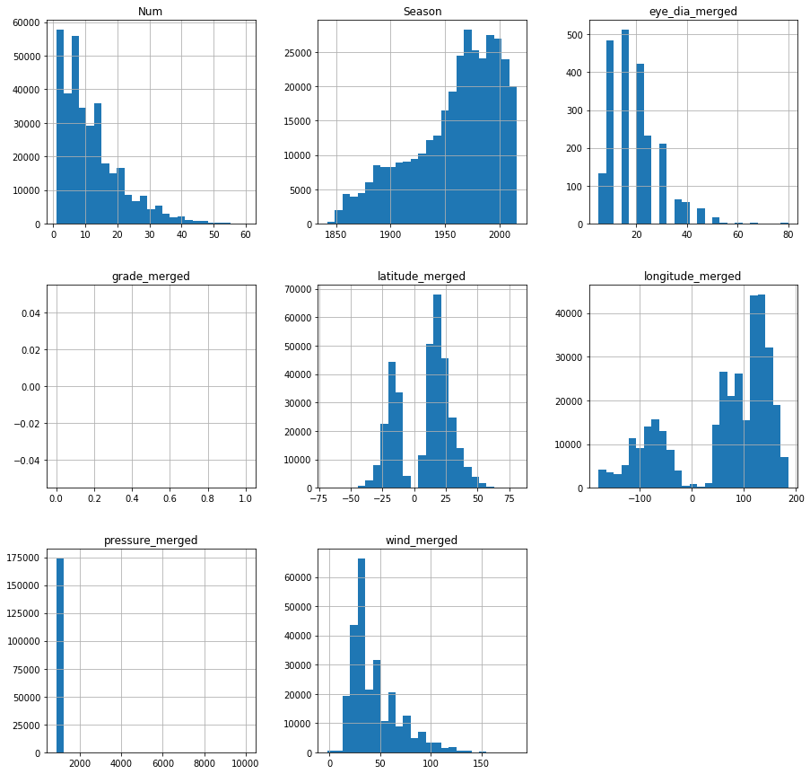

```python
ax_list = merged_df.hist(bins=25, layout=(3,3), figsize=(15,15))
```

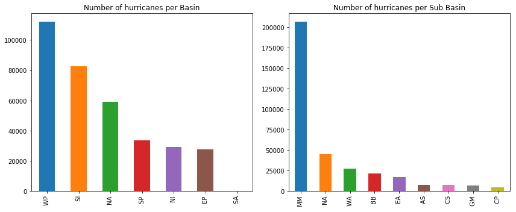

```python
fig2, ax2 = plt.subplots(1,2, figsize=(12,5))

merged_df['Basin'].value_counts().plot(kind='bar', ax=ax2[0], title="Number of hurricanes per Basin")
merged_df['Sub_basin'].value_counts().plot(kind='bar', ax=ax2[1], title="Number of hurricanes per Sub Basin")
plt.tight_layout()
```

```python
merged_df['eye_dia_merged'].value_counts()
```

```
15.0    512
10.0    483
20.0    422
25.0    233
30.0    210
5.0     133
35.0     64
40.0     56
45.0     39
50.0     16
80.0      3
60.0      3
55.0      1
65.0      1
Name: eye_dia_merged, dtype: int64
```

```python
merged_df['grade_merged'].value_counts()
```

```
Series([], Name: grade_merged, dtype: int64)
```

```
(850, 1050)
```

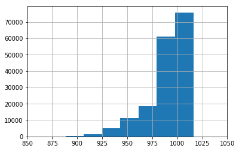

```python
ax = merged_df['pressure_merged'].hist(bins=500)
ax.set_xlim(850,1050)
```